# MTH6139 Time Series

Time Series Analysis of AI Venture Capital Investment

Elion Qerimi

12th March 2026

[figure not shown]

# Introduction

The aim of this project is to analyse worldwide venture capital investment in artificial intelligence and to produce forecasts using Meta’s Prophet model in R. Venture capital investment is a useful indicator of confidence in AI-related businesses, since it reflects how much funding investors are willing to commit to this sector.

The dataset used in this project was downloaded from the OECD AI data portal. It contains yearly values of worldwide AI-related venture capital investment, measured in USD millions, from 2012 onwards.

# Data description and preparation

First, I will load the dataset and inspect its structure.

```r
ai_raw <- read.csv(file.path("Data", "data.csv"))

head(ai_raw)
```

```
##                 Category Quarter Sum_of_deals
## 1 AI-related investments    2012      8373.09
## 2 AI-related investments    2013     10924.88
## 3 AI-related investments    2014     27275.03
## 4 AI-related investments    2015     42314.65
## 5 AI-related investments    2016     45074.99
## 6 AI-related investments    2017     73278.74
```

```r
names(ai_raw)
```

```
## [1] "Category"     "Quarter"      "Sum_of_deals"
```

```r
str(ai_raw)
```

```
## 'data.frame':    14 obs. of  3 variables:
##  $ Category    : chr  "AI-related investments" "AI-related investments" "AI-related investments" "AI-related investments" ...
##  $ Quarter     : int  2012 2013 2014 2015 2016 2017 2018 2019 2020 2021 ...
##  $ Sum_of_deals: num  8373 10925 27275 42315 45075 ...
```

```r
summary(ai_raw)
```

```
##    Category            Quarter      Sum_of_deals
##  Length:14          Min.   :2012   Min.   :  8373
##  Class :character   1st Qu.:2015   1st Qu.: 43005
##  Mode  :character   Median :2018   Median : 98092
##                     Mean   :2018   Mean   :105421
##                     3rd Qu.:2022   3rd Qu.:145374
##                     Max.   :2025   Max.   :258674
```

The original dataset contains three columns: `Category`, `Quarter`, and `Sum_of_deals`. In this dataset, the `Quarter` column contains yearly values. Prophet requires the data to be stored in a dataframe with two columns called `ds` and `y`, where `ds` contains dates and `y` contains the numeric values to forecast.

```r
ai_data <- data.frame(
  ds = as.Date(paste(ai_raw$Quarter, "-01-01", sep = "")),
  y = ai_raw$Sum_of_deals
)

head(ai_data)
```

```
##           ds        y
## 1 2012-01-01  8373.09
## 2 2013-01-01 10924.88
## 3 2014-01-01 27275.03
## 4 2015-01-01 42314.65
## 5 2016-01-01 45074.99
## 6 2017-01-01 73278.74
```

```r
summary(ai_data)
```

```
##        ds                   y
##  Min.   :2012-01-01   Min.   :  8373
##  1st Qu.:2015-04-02   1st Qu.: 43005
##  Median :2018-07-02   Median : 98092
##  Mean   :2018-07-02   Mean   :105421
##  3rd Qu.:2021-10-01   3rd Qu.:145374
##  Max.   :2025-01-01   Max.   :258674
```

# Exploratory analysis

Before fitting a forecasting model, it is useful to plot the time series.

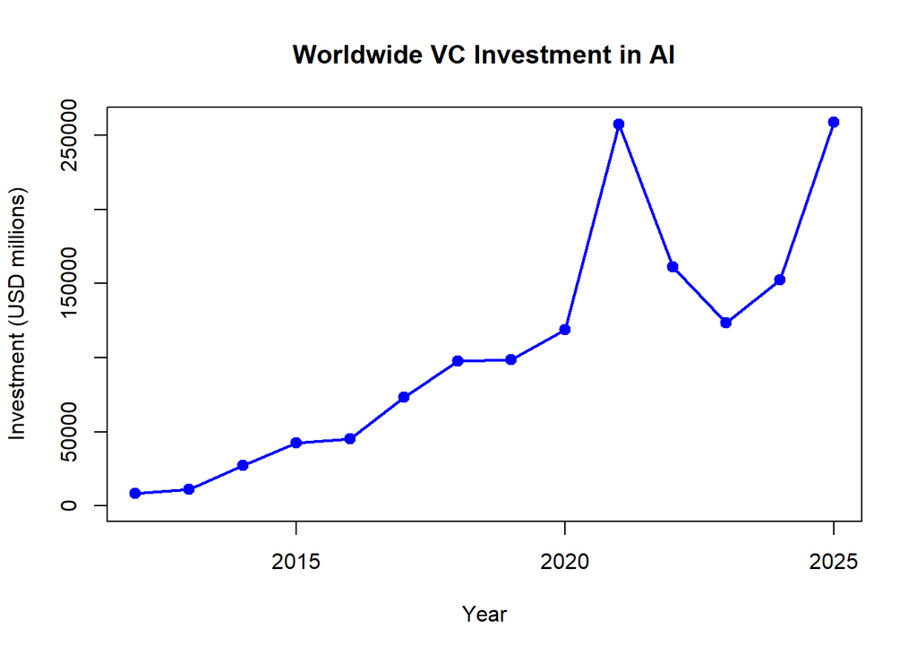

```r
plot(ai_data$ds, ai_data$y,
     type = "o",
     col = "blue",
     pch = 19,
     lwd = 2,
     xlab = "Year",
     ylab = "Investment (USD millions)",
     main = "Worldwide VC Investment in AI",
     ylim = c(0, max(ai_data$y)))
```

To better understand the changes in the series, I display the yearly values of the dataset. This allows me to verify the exact investment levels for each year and helps explain the movements observed in the plot above.

```r
print(ai_data)
```

```
##            ds         y
## 1  2012-01-01   8373.09
## 2  2013-01-01  10924.88
## 3  2014-01-01  27275.03
## 4  2015-01-01  42314.65
## 5  2016-01-01  45074.99
## 6  2017-01-01  73278.74
## 7  2018-01-01  97591.73
## 8  2019-01-01  98593.04
## 9  2020-01-01 118752.43
## 10 2021-01-01 257349.34
## 11 2022-01-01 161472.32
## 12 2023-01-01 123579.89
## 13 2024-01-01 152638.35
## 14 2025-01-01 258673.96
```

# A simple linear trend check

As an additional check, I fit a simple linear regression of investment against time.

```r
ai_data$time_index <- 1:nrow(ai_data)

linear_model <- lm(y ~ time_index, data = ai_data)
summary(linear_model)
```

```
##
## Call:
## lm(formula = y ~ time_index, data = ai_data)
##
## Residuals:
##    Min     1Q Median     3Q    Max
## -58117 -14501  -3527    167 109553
##
## Coefficients:
##             Estimate Std. Error t value Pr(>|t|)
## (Intercept)   -21707      23220  -0.935    0.368
## time_index     16950       2727   6.216 4.48e-05 ***
## ---
## Signif. codes:  0 '***' 0.001 '**' 0.01 '*' 0.05 '.' 0.1 ' ' 1
##
## Residual standard error: 41130 on 12 degrees of freedom
## Multiple R-squared:  0.763,  Adjusted R-squared:  0.7432
## F-statistic: 38.63 on 1 and 12 DF,  p-value: 4.481e-05
```

The slope coefficient 16950 means on average, AI venture capital investment increases by roughly 17000 million USD per year.This confirms the upward trend we saw in the plot. A p-value of 4.48e-05 is very small which implies the upward trend is statistically significant and unlikely to be due to random variation. Multiple R-Squared being 0.763 means the linear trend explains about 76% of the variation in AI VC investment. That is quite high, implying the trend captures most of the movement in the data.

# Log transformation

Because the level of the series increases substantially over time, it is also useful to consider a logarithmic transformation. This can reduce the effect of very large values and make the growth pattern easier to interpret.

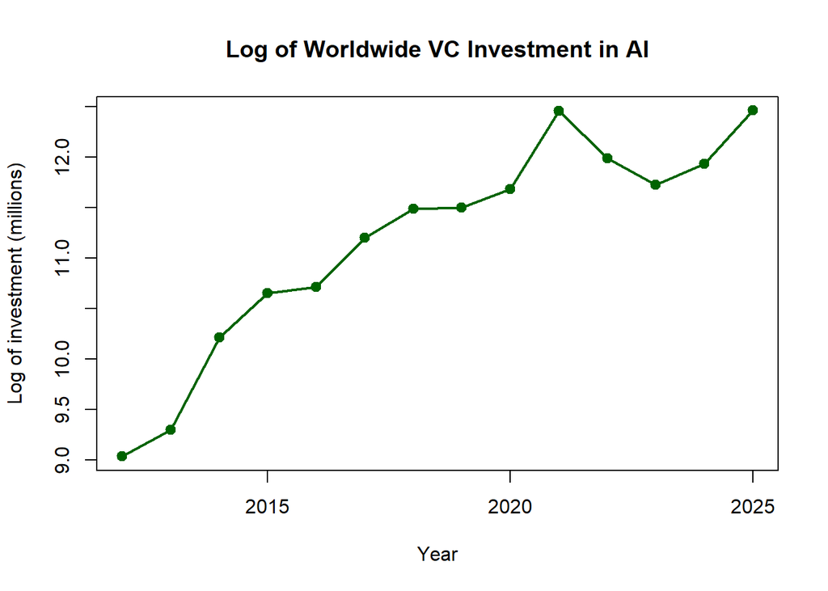

```r
log_ai_data <- data.frame(
  ds = ai_data$ds,
  y = log(ai_data$y)
)

plot(log_ai_data$ds, log_ai_data$y,
     type = "o",
     col = "darkgreen",
     pch = 19,
     lwd = 2,
     xlab = "Year",
     ylab = "Log of investment (millions)",
     main = "Log of Worldwide VC Investment in AI")
```

# Prophet forecasting model

I now fit Meta’s Prophet model to the original time series.

```r
library(prophet)
ai_model <- prophet(ai_data,
                    yearly.seasonality = FALSE,
                    weekly.seasonality = FALSE,
                    daily.seasonality = FALSE)
```

```
## n.changepoints greater than number of observations. Using 10
```

Since the dataset contains yearly observations, I switch off the seasonal components and focus on modelling the trend.

# Forecasting future investment

I forecast the series forward by 5 years.

```r
future_dates <- make_future_dataframe(ai_model, periods = 5, freq = "year")

forecast <- predict(ai_model, future_dates)
```

# Forecast plot

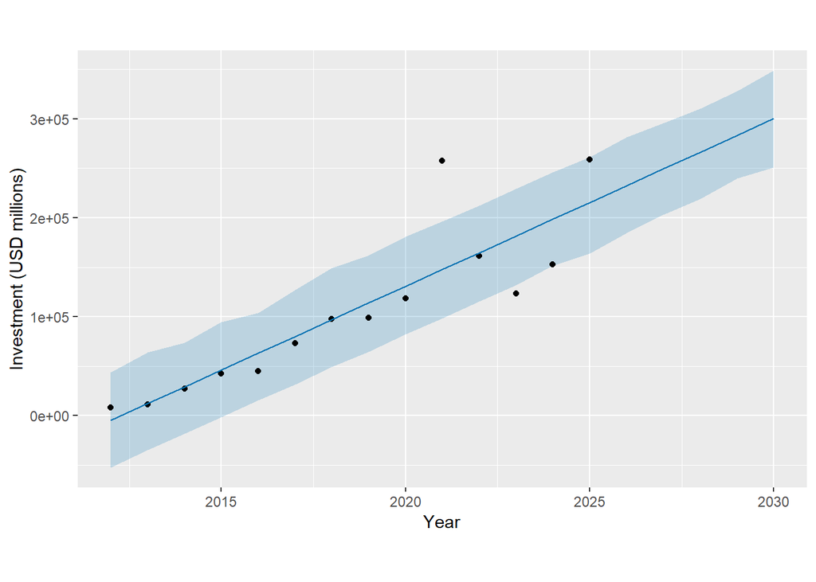

```r
plot(ai_model, forecast,
     xlab = "Year",
     ylab = "Investment (USD millions)",
     main = "Forecast of Worldwide VC Investment in AI")
```

The plot shows the Prophet forecast for worldwide AI venture capital investment. The black dots are the actual historical observations, while the blue line shows the model’s estimated trend and future predictions. The shaded area represents the uncertainty interval, showing the range where future investment values are likely to fall.

Some of the observed points lie noticeably above or below the predicted trend line, particularly the large spike around 2021. In some cases these points also fall outside or close to the edge of the uncertainty band. This suggests that the model does not fully capture sudden changes in investment levels. These deviations may reflect unusual market conditions, such as the surge in technology investment during the post-pandemic period.

# Forecast values

To inspect the forecast more closely, I display the last few fitted and forecast values below.

```r
tail(forecast)
```

```
##            ds    trend zeros zeros_lower zeros_upper additive_terms
## 14 2025-01-01 215556.2     0           0           0              0
## 15 2026-01-01 232484.3     0           0           0              0
## 16 2027-01-01 249412.5     0           0           0              0
## 17 2028-01-01 266340.7     0           0           0              0
## 18 2029-01-01 283315.2     0           0           0              0
## 19 2030-01-01 300243.4     0           0           0              0
##    additive_terms_lower additive_terms_upper multiplicative_terms
## 14                    0                    0                    0
## 15                    0                    0                    0
## 16                    0                    0                    0
## 17                    0                    0                    0
## 18                    0                    0                    0
## 19                    0                    0                    0
##    multiplicative_terms_lower multiplicative_terms_upper yhat_lower yhat_upper
## 14                          0                          0   163984.8   261310.9
## 15                          0                          0   184906.5   281289.5
## 16                          0                          0   203212.3   295852.5
## 17                          0                          0   218925.8   310603.9
## 18                          0                          0   240131.6   328295.8
## 19                          0                          0   251022.8   348894.8
##    trend_lower trend_upper     yhat
## 14    215556.2    215556.2 215556.2
## 15    232484.3    232484.3 232484.3
## 16    249412.5    249412.5 249412.5
## 17    266340.7    266340.7 266340.7
## 18    283315.2    283315.2 283315.2
## 19    300243.4    300243.4 300243.4
```

The table above shows the last few values produced by the Prophet model. The first row corresponds to the final observed year in the dataset (2025), while the remaining rows show the model’s forecast for the next five years. The trend column represents the estimated underlying trend in AI venture capital investment. The values suggest that investment is expected to continue increasing steadily over the forecast horizon, reaching approximately 300,000 (USD millions) by 2030.This projection follows the strong upward trend observed in the historical data.

# Discussion

Overall, the results suggest that worldwide venture capital investment in AI has increased substantially over the period observed. Investment rises from 8,373.09 USD millions in 2012 to 258,673.96 USD millions in 2025, indicating strong long-term growth. However, the series also contains some noticeable short-term fluctuations. In particular, there is a sharp increase in 2021, followed by declines in 2022 and 2023, before investment begins to rise again in 2024 and 2025. This shows that although the overall trend is upward, investment levels can still change quickly in response to wider economic or market conditions.

The Prophet model extends this trend into the future and suggests that AI-related venture capital investment may continue increasing over the next few years. However, the dataset is relatively short and consists of yearly observations, which limits the amount of detail the model can capture. Venture capital investment is also influenced by broader economic conditions, meaning that forecasts should be interpreted with some caution.

# Conclusion

This project analysed worldwide venture capital investment in AI using a time series dataset from the OECD AI data portal covering the period 2012–2025. The exploratory analysis showed a clear upward trend in investment over time, together with some fluctuations in recent years. A logarithmic transformation was also considered to help interpret the growth pattern of the series.

# References

- OECD AI data portal: https://oecd.ai/en/data
- Prophet documentation: https://facebook.github.io/prophet/docs/quick_start.html#r-api